# Exercise 8: differential expression with count data

Martin Holub

15/11/2017

In this exercise, we will explore two popular pipelines for differential expression of RNA-seq data, (already) given the counts. Details on the counting and/or of the transcript abundance estimation were covered in the last lecture from Hubert and more details will be given in Charlotte’s RNA-seq session. The dataset used here is the well-known ‘pasilla’ data, which compares the knockout of pasilla (a splicing factor) to a wild-type control.

In this exercise, some code will be given to get started. But, there are good resources on how to go through these fairly standard analysis pipelines (links below).

First, we have the samples already organized into a table of metadata and this is used to set the count filenames.

```r
library("edgeR")
samples <- read.table("data/samples.txt", header=TRUE,
                      row.names=5, stringsAsFactors=FALSE)
samples
```

```
##                   rep condition libtype shortname           countfile
## CG8144_RNAi-1.bam  T1         T      SE     T1.SE CG8144_RNAi-1.count
## CG8144_RNAi-3.bam  T3         T      PE     T3.PE CG8144_RNAi-3.count
## CG8144_RNAi-4.bam  T4         T      PE     T4.PE CG8144_RNAi-4.count
## Untreated-1.bam    C1         C      SE     C1.SE   Untreated-1.count
## Untreated-6.bam    C6         C      SE     C6.SE   Untreated-6.count
## Untreated-3.bam    C3         C      PE     C3.PE   Untreated-3.count
## Untreated-4.bam    C4         C      PE     C4.PE   Untreated-4.count
```

Here, we read in the 7 count files and consolidate it into a single table as opposed to 7 individual files – the readDGE() function saves having to do this manually:

```r
counts <- edgeR::readDGE(samples$countfile, path = "data/")$counts
```

Here, we can trim the column names to get a ‘nice’ grouping variable to use in the design matrix:

```r
grp <- gsub("\\-.[0-9]*","",colnames(counts))
grp
```

```
## [1] "CG8144_RNAi" "CG8144_RNAi" "CG8144_RNAi" "Untreated"   "Untreated"
## [6] "Untreated"   "Untreated"
```

Below is a pipeline using likelihood-ratio tests that is adapted from Quick Start section, early in the [edgeR user’s guide](http://bioconductor.org/packages/release/bioc/vignettes/edgeR/inst/doc/edgeRUsersGuide.pdf)

```r
group <- factor(grp)
y <- edgeR::DGEList(counts=counts, group=group)
y <- edgeR::calcNormFactors(y, method = "TMM") # adjust for different sizes of libraries
design <- model.matrix(~group)

y <- edgeR::estimateDisp(y,design) # estimate common, trended and tagwise dispersion
#To perform likelihood ratio tests:
fit <- edgeR::glmFit(y,design)
lrt <- edgeR::glmLRT(fit,coef=2) # DGELRT-class
edgeR::topTags(lrt)
```

```
## Coefficient:  groupUntreated
##                 logFC   logCPM       LR        PValue           FDR
## FBgn0039155  4.612728 5.713330 560.3984 6.885924e-124 1.048451e-119
## FBgn0039827  4.026942 4.244841 301.4369  1.602220e-67  1.219770e-63
## FBgn0025111 -2.932831 6.716692 292.5665  1.372001e-65  6.963361e-62
## FBgn0034736  3.533232 3.987363 222.2421  2.933166e-50  1.116510e-46
## FBgn0003360  3.168704 8.269281 219.2281  1.332778e-49  4.058576e-46
## FBgn0035085  2.525586 5.429273 206.6463  7.405792e-47  1.879343e-43
## FBgn0000071 -2.715199 4.578686 193.1763  6.442282e-44  1.401288e-40
## FBgn0029167  2.200346 8.025632 190.2500  2.803829e-43  5.336388e-40
## FBgn0029896  2.410059 5.092969 174.8458  6.469506e-40  1.094497e-36
## FBgn0034434  3.532031 3.007545 169.2943  1.055100e-38  1.606496e-35
```

This will lead you to a list of putative/detected differentially expressed genes. Note that the code above is just an example and is not actually run in the script.

#### Exercise 1: Fix the code above to work on the count table that was already read in. Add in some spot checks, including an MDS plot from plotMDS(), a look at the dispersion-mean plot using plotBCV() and a look at the overall M vs A plot using plotSmear().

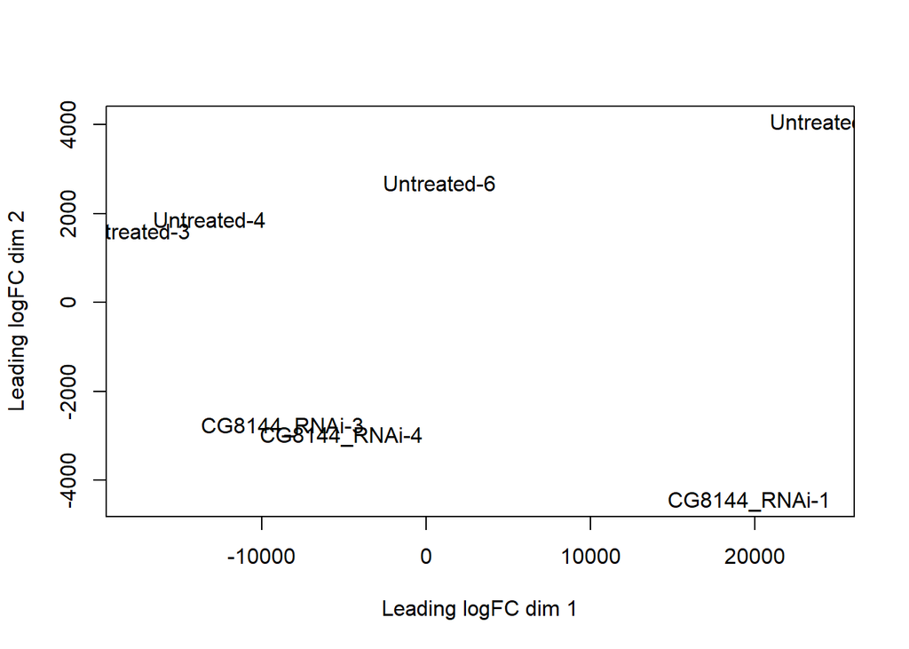

```r
limma::plotMDS(lrt$fitted.values)
```

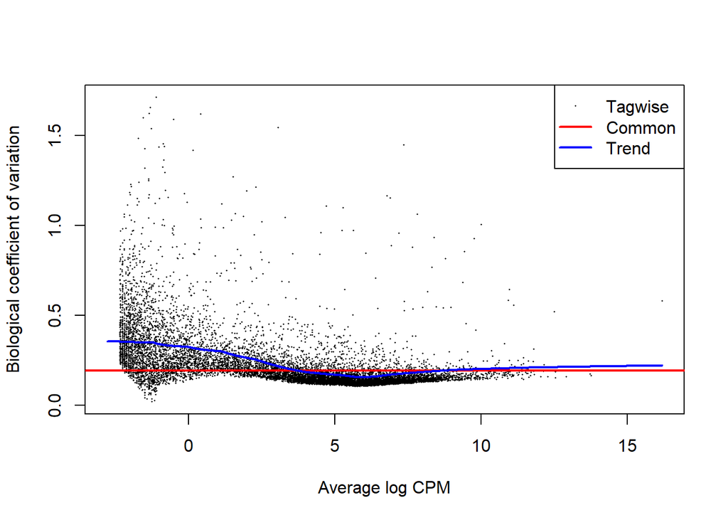

```r
edgeR::plotBCV(y) # counts per million
```

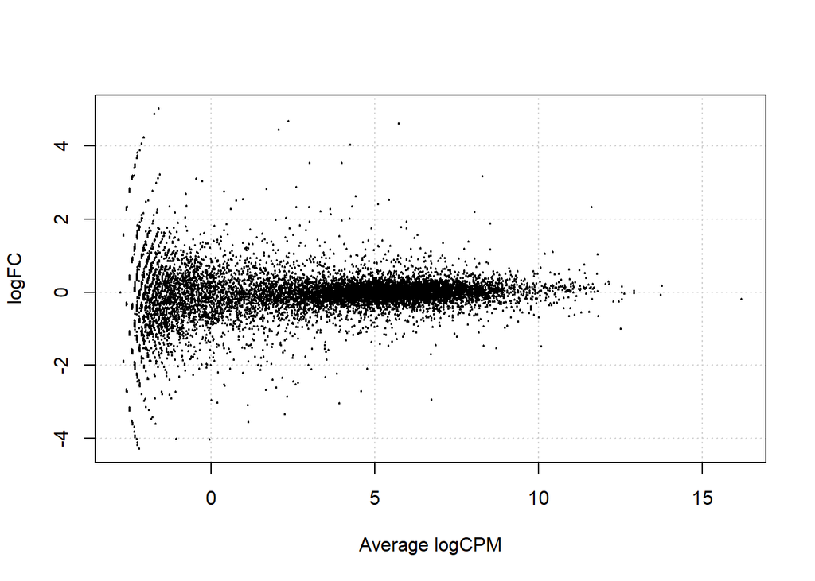

```r
# subpopulations with different variance can be seen, lowess regression
edgeR::plotSmear(lrt)
```

For more details, see Section 15.5 Differential expression of the [limma user’s guide](http://www.bioconductor.org/packages/devel/bioc/vignettes/limma/inst/doc/usersguide.pdf).

#### Exercise 2: For the MDS plot, investigate what happens differently when you call plotMDS() on the DGEList object and when you call it on the normalized counts – for normalized counts, see the cpm() function. Explain why it is different.

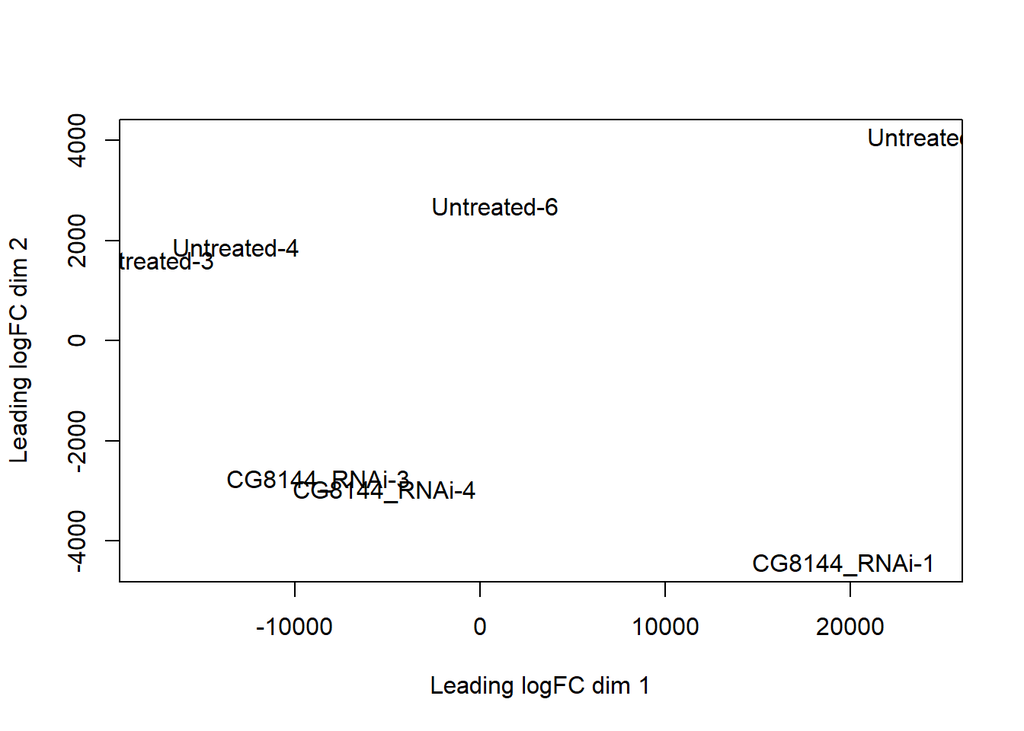

```r
limma::plotMDS(lrt$fitted.values)
```

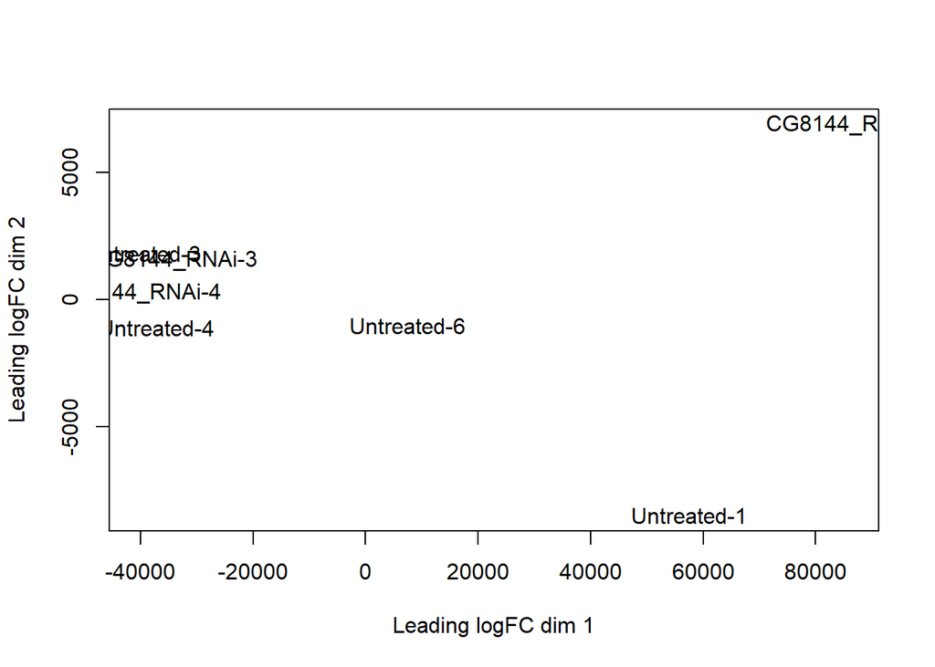

```r
limma::plotMDS(y$counts)
```

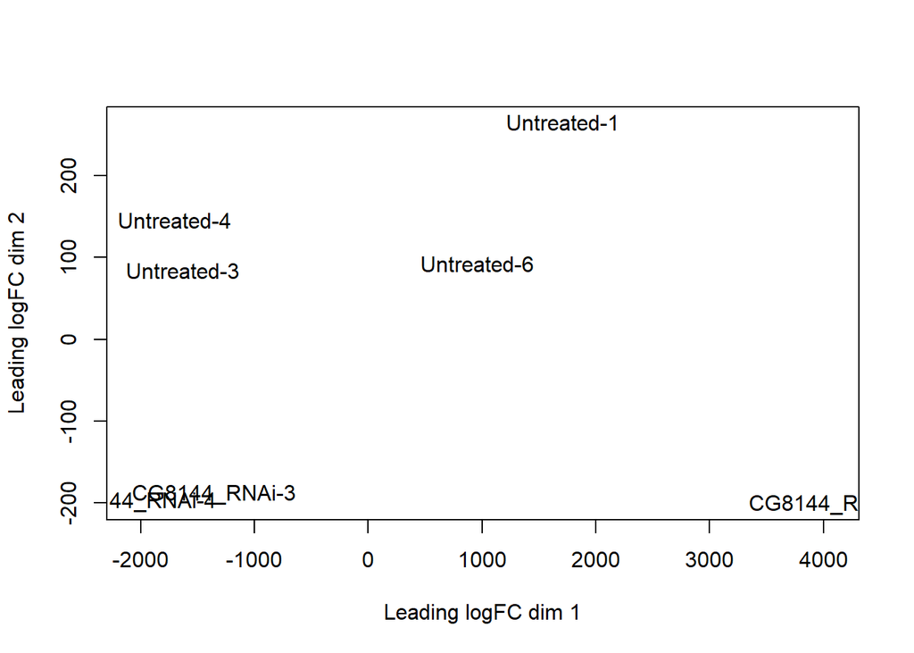

```r
limma::plotMDS(edgeR::cpm(y$counts))
```

Samples become linearly separable in the reduced two dimensonal MDS space for normalized counts.

As an alternative (to edgeR above), one can run through a standard voom pipeline, such as:

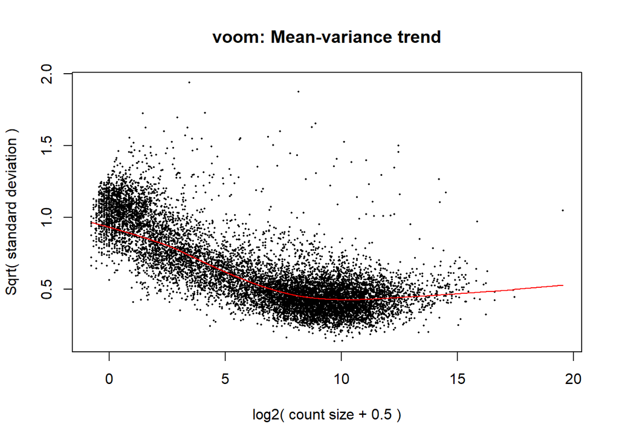

```r
v <- limma::voom(y$counts, design=design, plot = TRUE)
```

```r
vf = limma::lmFit(v, design = design)  # note similarity to limma
                                            # analysis performed earlier
vf = limma::eBayes(vf)
```

#### Exercise 3. Again, the above code for voom is not run here. Fix this code to work with the count dataset above and then do some ``spot checks’’ of the genes called DE. For example, make a plot of the plot of estimated fold changes for the two methods, compare the P-values of the two methods, or create a venn diagram of the called sets of DE genes at a set threshold.

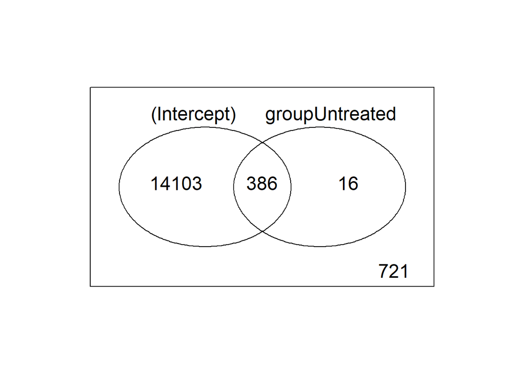

```r
test_res <- limma::decideTests(vf, method = "separate", p.value = 0.05, lfc = 0)
# An object of class TestResults. This is essentially a numeric matrix with elements -1, 0 or 1 depending on whether each t-statistic is classified as significantly negative, not significant or significantly positive.
limma::vennDiagram(test_res, include = "both")
```

```r
limma::topTable(vf, coef = 2)
```

```
##                 logFC  AveExpr         t      P.Value    adj.P.Val
## FBgn0003360  3.129974 7.590927  21.95612 1.732794e-10 1.319176e-06
## FBgn0039155  4.626326 4.498568  25.20636 3.857088e-11 5.872802e-07
## FBgn0029167  2.190542 7.670241  20.07038 4.583930e-10 2.326497e-06
## FBgn0025111 -2.955968 6.023921 -17.98461 1.495913e-09 5.694193e-06
## FBgn0029896  2.387550 4.665939  15.89875 5.595634e-09 1.419985e-05
## FBgn0035085  2.536649 4.971809  15.07711 9.836892e-09 1.796504e-05
## FBgn0039827  4.025961 3.248772  16.28047 4.344800e-09 1.323078e-05
## FBgn0000071 -2.758940 3.969925 -14.80962 1.189231e-08 1.796504e-05
## FBgn0051092 -2.326407 3.025255 -14.80722 1.191279e-08 1.796504e-05
## FBgn0262733 -2.109963 4.364669 -14.09082 2.011937e-08 2.356443e-05
##                     B
## FBgn0003360 14.321194
## FBgn0039155 14.301408
## FBgn0029167 13.501305
## FBgn0025111 12.421092
## FBgn0029896 11.081029
## FBgn0035085 10.599390
## FBgn0039827 10.524690
## FBgn0000071 10.384618
## FBgn0051092 10.228005
## FBgn0262733  9.947192
```

```r
# for comparison
edgeR::topTags(lrt)
```

```
## Coefficient:  groupUntreated
##                 logFC   logCPM       LR        PValue           FDR
## FBgn0039155  4.612728 5.713330 560.3984 6.885924e-124 1.048451e-119
## FBgn0039827  4.026942 4.244841 301.4369  1.602220e-67  1.219770e-63
## FBgn0025111 -2.932831 6.716692 292.5665  1.372001e-65  6.963361e-62
## FBgn0034736  3.533232 3.987363 222.2421  2.933166e-50  1.116510e-46
## FBgn0003360  3.168704 8.269281 219.2281  1.332778e-49  4.058576e-46
## FBgn0035085  2.525586 5.429273 206.6463  7.405792e-47  1.879343e-43
## FBgn0000071 -2.715199 4.578686 193.1763  6.442282e-44  1.401288e-40
## FBgn0029167  2.200346 8.025632 190.2500  2.803829e-43  5.336388e-40
## FBgn0029896  2.410059 5.092969 174.8458  6.469506e-40  1.094497e-36
## FBgn0034434  3.532031 3.007545 169.2943  1.055100e-38  1.606496e-35
```

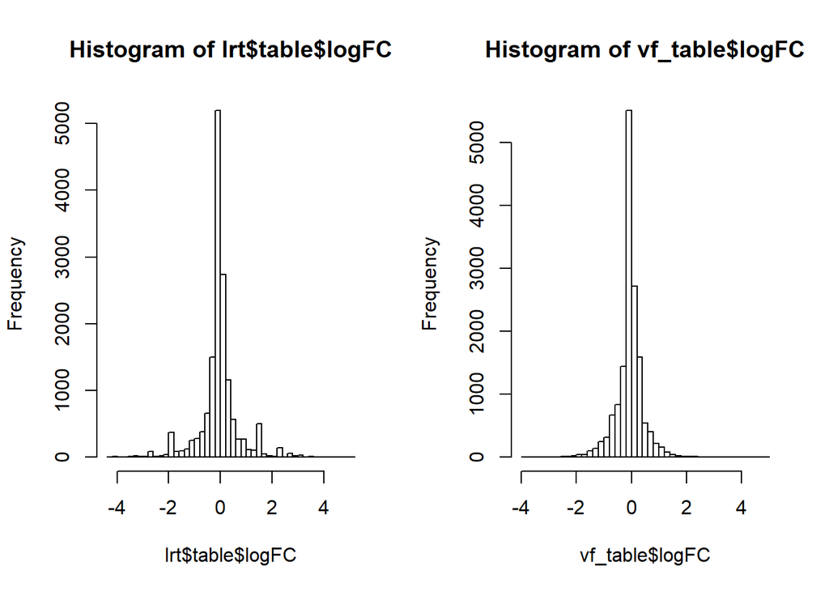

```r
par(mfrow=c(1,2))
vf_table <- topTable(vf, coef = 2, n=Inf)
hist(lrt$table$logFC, breaks = 50)
hist(vf_table$logFC, breaks = 50)
```

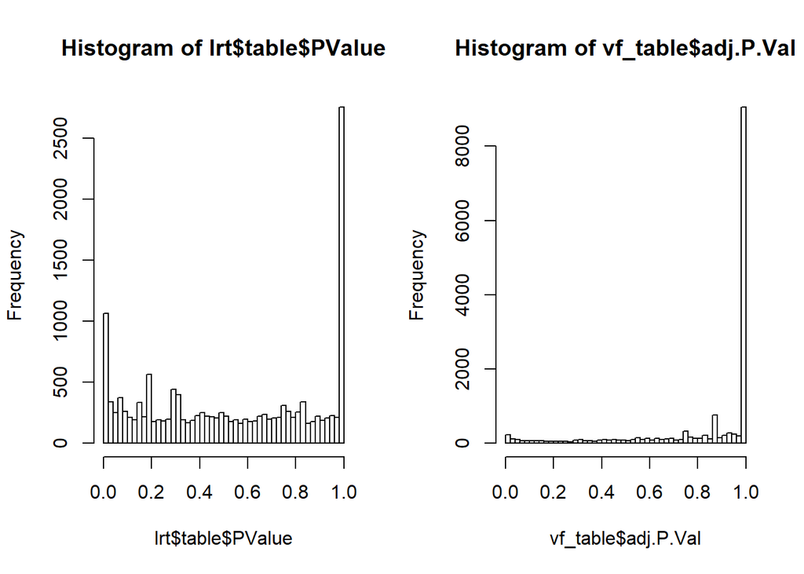

```r
par(mfrow=c(1,2))
vf_table <- topTable(vf, coef = 2, n=Inf)
hist(lrt$table$PValue, breaks = 50)
hist(vf_table$adj.P.Val, breaks = 50)
```